# Documentation of the extension of the fisheries composition dataset

#### 2.0.1.3 Carbohydates and other re-calculated variables

Then, we evaluated the difference in `CHOVALDg_std` values between the Fisheries Global NCT, 2022 (Feb) and the Fisheries Global NCT, 2022 (Oct).

Because CHOAVLDFg was re-calculated at Fishery (SUA) category, we evaluate CHO w/ and w/o NO21 (as we did w/ FAT). Check which categories are different (assuming prep).

We assumed that when CHOAVLDFg was negative, we assumed zero for both dataset. “Major differences (>0.5) were observed in six categories. The first two (with 2.1 and 1.7 point of difference) were due to”assumed zero” in the Fisheries Global NCT, 2022.

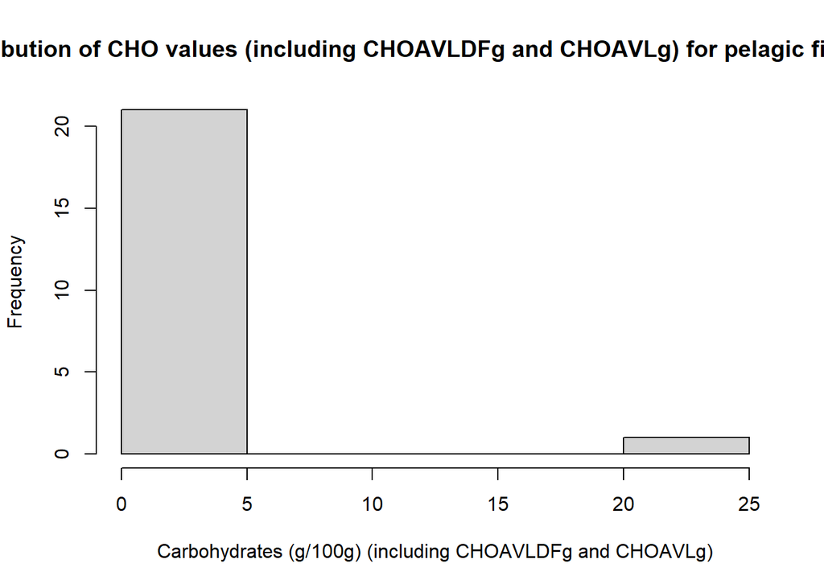

Most of the fishery products with CHO higher than zero are those within preparations, nei and cured and canned. The only “fresh”/“frozen” items with CHO > 0g were moluscs (eg. snails). Because CHO (CHOAVg) was analysed for NO21, ASHg were not reported thus, CHOAVLDFg could not be calculated. We evaluated the impact of using a different CHO method to the overall values. We could see that in NO21 there were some mean values that were higher than in the Fisheries Global NO21. For example, we found that within “Demersal fish, preparations nei” there quite number of fish entries that were “breaded”, thus the higher content in CHO. However, when compared wit other breaded items, the values seemed to be within range.

### 2.0.2 TO-DO: Value imputation

One of the main source of variability found when comparing the Fisheries Global NCT, Feb, 2022 (For sharing) compiled using excel, and the Fisheries Global NCT, Oct, 2022 compiled using R were the imputed values.

In this section we investigated some of the imputed values and the potential impact on the final values.

##### 2.0.2.0.1 Assumed zero values

**FIBTGg_std**

In the original Fisheries Global NCT,2022 there were some manually added “zero” as assumed values. These values were imported those in our dataset under “FIBTGg_std” variable. In addition, a comment was added indicating that the fibre value was assumed.

For the future development, check FAO/INFOODS to identify food group that may be “assumed” zero when calculating Carbohydrate by difference and Energy.(see Next steps: Assumed zero section).

##### 2.0.2.0.2 Recalculation from other components

**CARTBEQmcg**: Re-calculated from VITA_mcg and VITA_RAEmcg

**VITAmcg**: Imputed/ Re-calculated from Vitamin A (IU) which was imputed.

## 2.1 Next steps: Functions development and improvemnts

#### 2.1.0.1 Renaming variables

Overall - Allocate CDNO ontology codes to NV.

B13: - Get CARTBEQ or [CARTB] into two columns. - Remove function and change to pre-loading functions from source(functions.R).

DK19 -Rename all other NV w/ Tagnames. -Find a better renaming way.

NZ18 -Rename all NV w/ Tagnames, including sugars and Fatty Acids.

US21 - Using data embeded in US21 to allocate the Tagnames for all NVs.

#### 2.1.0.2 Characters in nutrient values

- A function that generate different columns for different analytical method of the same/similar component. E.g., Extracting alternative analitycal method (i.e., NIA for Niacin) that are provided in the same column of the preferred analytical method (i.e., NIAEQ for Niacin) but within bracket.This type of data structure was observed in BA13, KE18, and WA19.
- A function that extract the “estimated” values and/or low quality values between brackets or parenthesis, and it generate a metadata info on that. Eg. A new column with a string providing information on which values were low quality and/or estimated. This was observed in JA15, where the use of bracket to denote “estimated values”. We removed the brackets but we should look at how to keep a record and the meaning of estimated values. In KE18, “Low quality” values were reported within brackets.
- A function to change Trace values, expressed as “tr”, “Tr”, “<LOD”, to 0 (zero).

##### 2.1.0.2.1 Functions improvement for the future:

For the future development, check FAO/INFOODS to identify food group that certain components (e.g., fibre, alcohol, etc.) may be “assumed” zero when calculating Carbohydrate by difference and Energy, otherwise it should flag it as “missing value” need attention (see also “Assumed zero”).

For the function that re-calculate NIA, THIA and VITB6, documentation of the Tagname and/or re-calcuated value used should be added to the the documentation (`comment`).

###### 2.1.0.2.1.1 Dealing with missing nutrient values

##### 2.1.0.2.2 Assumed zero

-Fibre: We could check whether they are listed under fish or fish preparations. If preparations then check what type of preparation, otherwise we could assume zero. Current mean of FIBTGg = 0.29.

- Alcohol
- CHOAVLDF for non-processed foods.

##### 2.1.0.2.3 Imputing nutrient values

**Se concentration**: Mean mackerel fresh to (10157) (35055) with (35164), by water-adjusting and assuming the oil has no contribution to `Semcg`. Although, due to the low water content and overall high content in Se of the category, it would only increase the mean.

#### 2.1.0.3 Nutrient values

##### 2.1.0.3.1 DHA and EPA

Fats and fatty acids concentration in fish and aquatic animals varies widely. These components are very sensitive to many environmental, seasonal and other changes. Hence, imputing missing values is not optimal. Therefore, including more fishery entries with minimal missing values should be sought in the future.

#### 2.1.0.4 Niacin Eq.

Total niacin equivalent (NIAEQ) = niacin preformed (NIA) + 1/60 tryptophan (TRP)

#### 2.1.0.5 Unit conversion

Unit conversion (when possible) to match Tagnames (per 100g EP FW)

- Alcohol(w/v) to (w/100g) = ALC (g/100mL) / density (g/mL) = ALC (g/100 EP)

### 2.1.1 6. Updating the Fisheries Global NCT

Final data formatting operations were carried in excel. For instance, table headings were adjusted in excel to keep consistency with R format. If a column (variable) contain text would be converted into an object with class “character”, which then would be exported into excel as text losing the decimals and the ability to do further calculations if needed. Similarly, background colours and conditional formatting were manually added in excel.

# 3 Recommendations for the future

## 3.1 More food composition analysis

## 3.2 Food composition tables and data quality

- FCT reusing food components: are we using the same value three times (e.g. in WA19 and KE18 imputed a value from IN17) what’s the impact in the final mean? And, what do it mean for the (lack of) variability in certain food component for certain food/ fish items?
- Information regarding data quality is sometimes provided in FCTs (e.g., using \[\] or other symbols to denote low quality), however most of the case this values are still used when generating NCTs (due to missing data). Could we account/ measure the impact of using this values in final estimates? Would be possible to generate a quality scale using these values? For example, could we count the number of low quality values (or the percentage) and establish a threshold for exclusion or at least to “flag” that estimate as highly uncertain.

## 3.3 Rethinking fisheries categories for nutrition

## 3.4 Data imputation and impact of summary statistics

## 3.5 Data documentation and data resuse

[^1]: Note: UP17 was not process because we were only interested in fish